# The Effects of Monthly Loan Payments and the Employment Status on Prosper Score and Borrower Annual Percentage Rating(APR)

## Investigation Overview

In thi sinvestigation, I wanted to look at how the monthly loan payments and the employment status could affect the prosper score and the borrower APR

## Dataset Overview

The Prosper loan dataset consists of 113937 loan entries with 81 feature3s for each loan spanning the years 2009 to 2014, including loan amount, borrower rate (or interest rate), current loan status, borrower income, and many others.

## Distribution of Prosper Score

The Prosper Score has a normal distribution with its peak at 4.0, 6.0 and 8.0 respectively

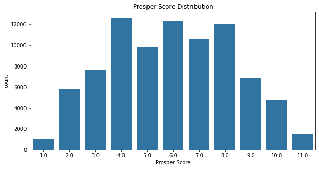

## Distribution of Prosper Rating

The prosper rating is normally distributed and most loans has a prosper rating of C.

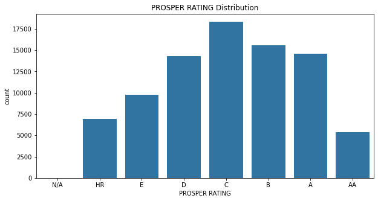

## Distribution of Borrower APR

The borrowers's annual peercentage rate is normally distributed with its peak at about 20% per annum. Also we note that there is a rapid increase in frequency before the 35% mark.

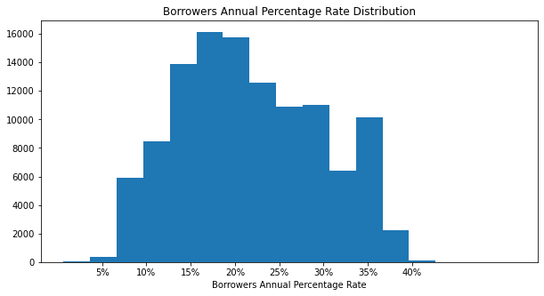

## Distribution of Borrower Rate

The borrower rate is also normally distributed and the borrower rate for most of the loans is between 15% and 20%

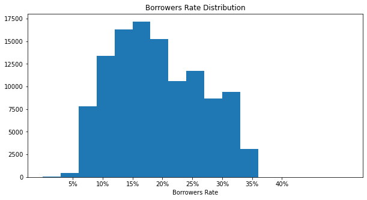

## Prosper Score and Rate Against Borrower APR and Rate

[figure not shown]

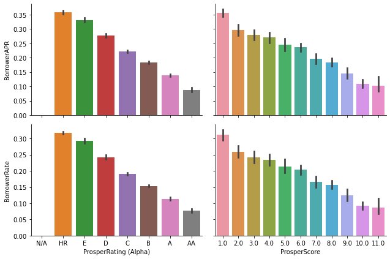

## Prosper Score and Rating against Monthly Loan Payment and Stated Monthly Income

[figure not shown]

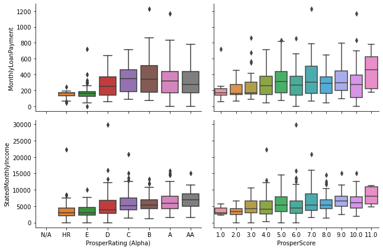

## Employment Status VS. Borrower APR

The unemployed have higher borrower APR than the employed

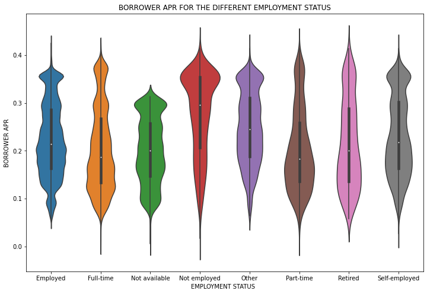

[output not shown]